# Examen Minería de Datos

Segundo Bimestre

01 de marzo de 2021

**Apellidos**: Amagua Obando

**Nombre**: Luis Fabian

# Contexto del problema

Con el objetivo de mejorar los tiempos de atención al cliente en ventanilla de un Banco, se ha recolectado información anónimamente de cada cajero y transacción realizada. Para el estudio, el Banco ha suministrado un archivo de excel con tres hojas:

- Sucursal: tiene información de las transacciones, columnas: Sucursal, Cajero, ID Transacción, Transacción, Tiempo Servicio seg, Nivel de satisfacción, Monto de la transacción.
- Data_Sucursal: información referente a la ubicación y si en la sucursal se ha puesto o no un nuevo sistema.
- Data_Cajero: información referente a datos del cajero.

Nota: Es necesario tener presente los tipos de datos que tenemos en el archivo de excel, para cada una de las hojas. Por ejemplo, en la hoja Sucursal: La variable Sucursal, debe ser considerada como una variable categórica nominal (en R se considera a las variables categóricas como factores); Cajero: La variable Cajero, es una variable categórica nominal; IDTransaccion: La variable IDTransaccion,es una variable categórica nominal; Transaccion: La variable Transaccion, es una variable categórica nominal; TiempoServicioseg: La variable TiempoServicioseg, es una variable numérica; Satisfaccion: La variable Satisfaccion, es una variable categórica ordinal; Monto: La variable Monto, es una variable numérica.

**Cambiamos los tipos de datos**

```r
# Leer el archivo de excel
data_banco <- read.xlsx(xlsxFile = "Data/Data_Banco.xlsx", sheet = "Sucursal")
data_sucursal <- read.xlsx(xlsxFile = "Data/Data_Banco.xlsx", sheet = "Data_Sucursal")
data_cajero <- read.xlsx(xlsxFile = "Data/Data_Banco.xlsx", sheet = "Data_Cajero")

#vemos el tipo de dato de la data_banco

str(data_banco)
```

```
## 'data.frame':    24299 obs. of  7 variables:
##  $ Sucursal           : num  62 62 62 62 62 62 62 62 62 62 ...
##  $ Cajero             : num  4820 4820 4820 4820 4820 4820 4820 4820 4820 4820 ...
##  $ ID_Transaccion     : chr  "2" "2" "2" "2" ...
##  $ Transaccion        : chr  "Cobro/Pago (Cta externa)" "Cobro/Pago (Cta externa)" "Cobro/Pago (Cta externa)" "Cobro/Pago (Cta externa)" ...
##  $ Tiempo_Servicio_seg: num  311 156 248 99 123 172 140 247 183 91 ...
##  $ Satisfaccion       : chr  "Muy Bueno" "Malo" "Regular" "Regular" ...
##  $ Monto              : num  2889 1671 3172 1765 1836 ...
```

```r
data_banco <- data_banco %>% mutate(Monto = str_replace(Monto, pattern = ",", replacement = ".")) %>%
    mutate(Sucursal = as.character(Sucursal), Cajero = as.character(Cajero), Satisfaccion = parse_factor(Satisfaccion,
        levels = c("Muy Malo", "Malo", "Regular", "Bueno", "Muy Bueno"), ordered = T),
        Monto = parse_number(Monto, locale = locale(decimal_mark = ".")))
```

```r
str(data_banco)
```

```
## 'data.frame':    24299 obs. of  7 variables:
##  $ Sucursal           : chr  "62" "62" "62" "62" ...
##  $ Cajero             : chr  "4820" "4820" "4820" "4820" ...
##  $ ID_Transaccion     : chr  "2" "2" "2" "2" ...
##  $ Transaccion        : chr  "Cobro/Pago (Cta externa)" "Cobro/Pago (Cta externa)" "Cobro/Pago (Cta externa)" "Cobro/Pago (Cta externa)" ...
##  $ Tiempo_Servicio_seg: num  311 156 248 99 123 172 140 247 183 91 ...
##  $ Satisfaccion       : Ord.factor w/ 5 levels "Muy Malo"<"Malo"<..: 5 2 3 3 5 4 3 4 5 5 ...
##  $ Monto              : num  2889 1671 3172 1765 1836 ...
```

```r
str(data_sucursal)
```

```
## 'data.frame':    5 obs. of  3 variables:
##  $ ID_Sucursal  : num  62 85 267 443 586
##  $ Sucursal     : chr  "Riocentro Sur" "Centro" "Alborada" "Mall del Sol" ...
##  $ Nuevo_Sistema: chr  "No" "Si" "Si" "Si" ...
```

```r
# debemos tener el mismo tipo de datos
data_sucursal <- data_sucursal %>% mutate(ID_Sucursal = as.character(ID_Sucursal))

# cambio el nombre de la variable sucursal por ID_sucursal de data_banco y le unimos a la data_sucursal
data_banco <- data_banco %>% rename(ID_Sucursal = "Sucursal") %>% left_join(data_sucursal,
    by = c("ID_Sucursal"))
str(data_banco)
```

```
## 'data.frame':    24299 obs. of  9 variables:
##  $ ID_Sucursal        : chr  "62" "62" "62" "62" ...
##  $ Cajero             : chr  "4820" "4820" "4820" "4820" ...
##  $ ID_Transaccion     : chr  "2" "2" "2" "2" ...
##  $ Transaccion        : chr  "Cobro/Pago (Cta externa)" "Cobro/Pago (Cta externa)" "Cobro/Pago (Cta externa)" "Cobro/Pago (Cta externa)" ...
##  $ Tiempo_Servicio_seg: num  311 156 248 99 123 172 140 247 183 91 ...
##  $ Satisfaccion       : Ord.factor w/ 5 levels "Muy Malo"<"Malo"<..: 5 2 3 3 5 4 3 4 5 5 ...
##  $ Monto              : num  2889 1671 3172 1765 1836 ...
##  $ Sucursal           : chr  "Riocentro Sur" "Riocentro Sur" "Riocentro Sur" "Riocentro Sur" ...
##  $ Nuevo_Sistema      : chr  "No" "No" "No" "No" ...
```

# Enunciado del problema:

Determinar la tipología de las transacciones a través del uso de métodos de clasificación, además dentro de cada clase realizar el perﬁlamiento de los cajeros que tiene el banco para la clase. Debido a la cantidad de transacciones, se recomienda realizar una caracterización (puede ser en función del volumen, monto, tiempo, etc.) que mínimo este consituida por tres clases. Para la caracterización puede utilizar un índice (componentes princiales) que permita realizar un ranking y definir las clases.

Una vez, que se tenga creada las clases utilizar la metodología de machine learning para validar y seleccionar un modelo que mejor clasifique la caracterización realizada.

Por otro lado, como bono de un punto para cada clase puede aplicar un método de clustering para descubir la tipología de los cajeros en función del nivel de satisfacción evaluado por el cliente, considerando los tiempos de servicio que dependen del tipo de transacción. Además, de otras características que considere que puedan describir el perfil del cajero.

## 1.- (40%) Caracterización de las transacciones.

**Determine almenos 3 clases que permitan caracterizar las transacciones con el objetivo de evaluar y mejorar los tiempos de atención.**

Vamos agrupar por kmeans

```r
# Consideremos la data solo con las varaiblaes numericas
library(PCAmixdata)
library(cluster)
library(factoextra)
#tomamos los datos numericos
data_num<-data.frame(data_banco$Monto, data_banco$Tiempo_Servicio_seg)
# Asignación de semilla para resultados reproducibles
```

## Numero Optimo de Cluster para los datos

```r
library(factoextra)
library(NbClust)
library(caret)
```

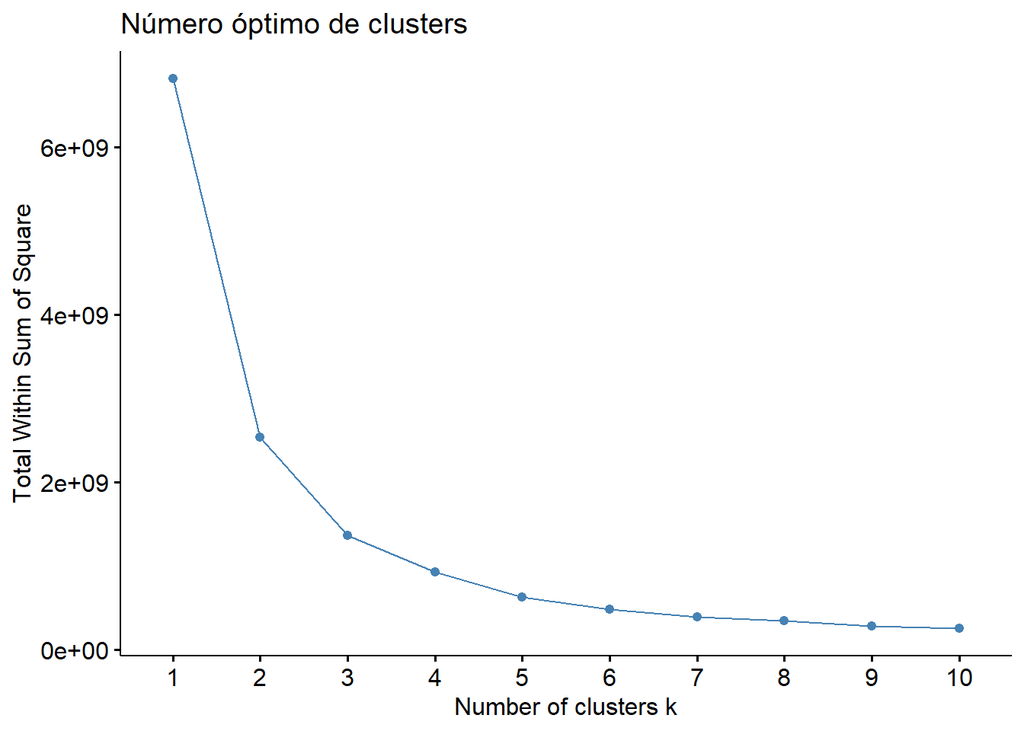

```r
#tomamos una muestra por la gran cantidad de datos, si tomamos todos los datos el tiempo de ejeccion es muy grande , ademas nos dice que no se crea un vector de 2.2 GB
muestra<- sample(1:nrow(data_num),size=10000,replace=FALSE)
muestra2<- data_num[muestra, ]

fviz_nbclust(x = muestra2, FUNcluster = kmeans, method = "wss", k.max = 10) +
   labs(title = "Número óptimo de clusters")
```

Vamos tomar 3 grupos para la clasificacion.

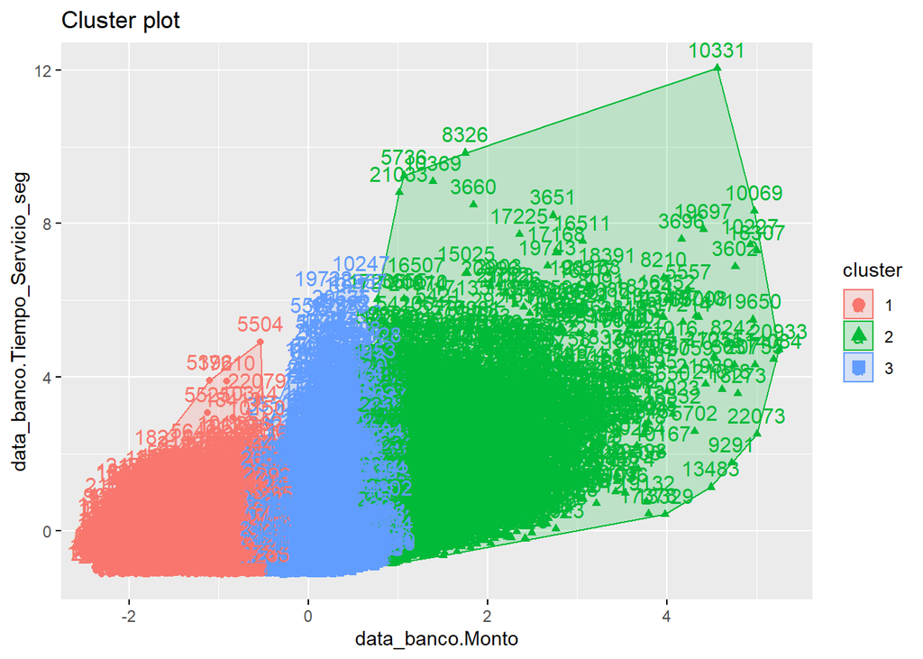

```r
set.seed(2)

km.res <- kmeans(data_num, 3, nstart = 25)
fviz_cluster(km.res, data = data_num, frame.type = "convex")
```

Se han considerado estos tres clusters de colores: verde, azul y rojo.

- grupo1: se encuentran transacciones de menor monto y menor tiempo de servicio
- grupo2: se encuentran transacciones de monto alto y alto tiempo de servicio medio
- grupo3: se encuentran transacciones monto medio y mediano tiempo de servicio

observems que en el cluster2 existe presencia de datos atipicos.

Ademas podemos ver la cantdad de observaciones en cada uno de los grupos:

[figure not shown]

```r
#estandarizacion
sucursal_scale<-scale(cluster2$data_banco.Monto)

#tomamos un k=20
sucursal_lof <- lof(sucursal_scale, k=20)

#CON EL METODO LOF CONSEGUIMOS EL INDICADOR
sucursal_lof<-as.data.frame(sucursal_lof)

# TENEMOS LA BASE CON SU INDICADOR DE ATIPICO O NO
atipicos<-data.frame(cluster2,sucursal_lof)

# sin atipicos
# metodo LOF: si son menores o iguales a uno es menos probable de que sean datos anomalos
sn_atipicos<-filter(atipicos,sucursal_lof<=1)
```

vemos si se eliminaron los atipicos

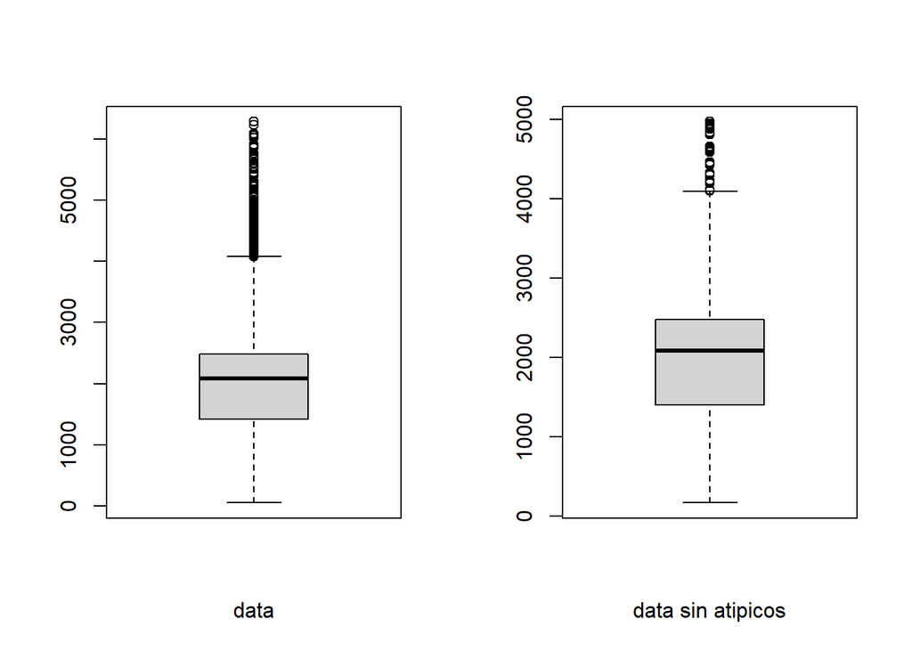

```r
par(mfrow=c(1,2))
boxplot(cluster2$data_banco.Monto,xlab = "data")
boxplot(sn_atipicos$data_banco.Monto,xlab = "data sin atipicos")
```

Ahora, sin atipicos tenemos:

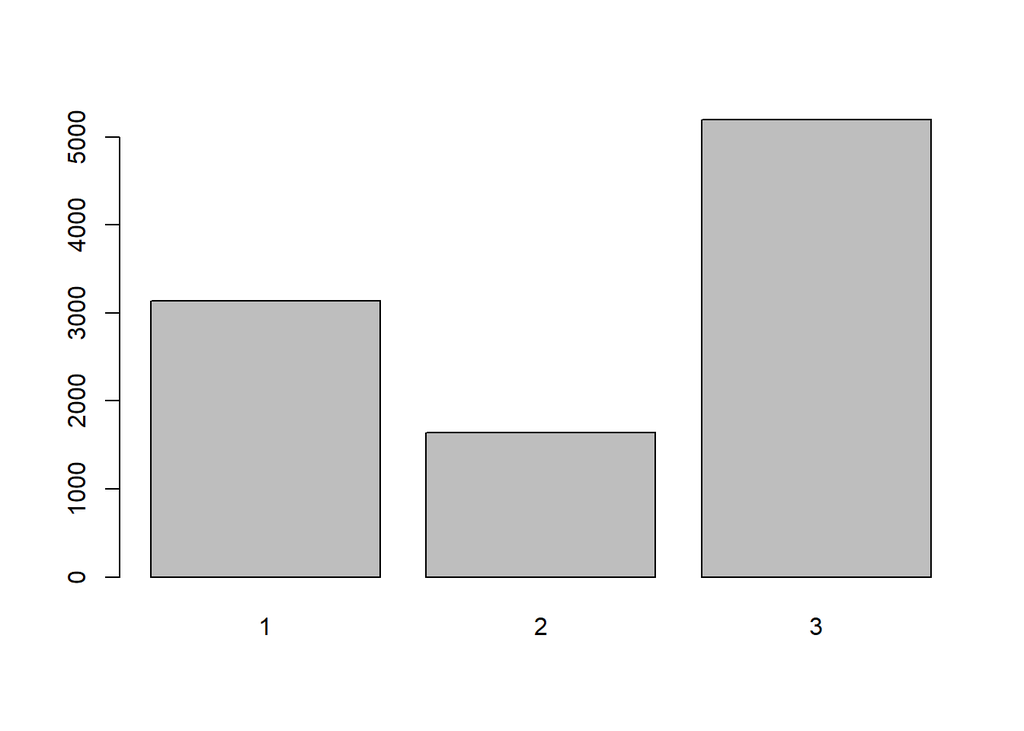

```r
barplot(table(sn_atipicos$km.res.cluster))
```